# Regressão linear

## 1. Importando as bibliotecas

## 2. Descrição e Dados

Neste documento, vamos utilizar regressão para analisar uma amostra de dados. Esses dados foram coletados a partir das avaliações discentes de final de semestre de uma grande amostra de professores da Universidade do Texas em Austin. As avaliações são feitas anonimamente, o que significa que os professores não sabem quem realizou as avaliações. Além disso, seis estudantes avaliaram a aparência física dos professores, representados na figura abaixo pelas variáveis bty_*. O resultado é um banco de dados no qual cada linha contém diferentes disciplinas e cada coluna representa as variáveis sobre as disciplinas e os professores. As variáveis contidas nele estão representadas na figura abaixo.

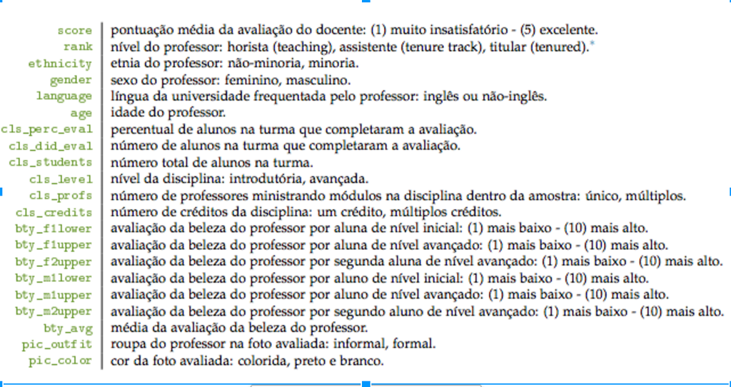

**Figura 1:** Variáveis e suas descrições

Nossa análise busca entender a relação entre a aparência física do professor e as avaliações recebidas por ele dos alunos. Examinaremos a hipótese de que a beleza do professor influencia na percepção de competência dos alunos.

Agora, vamos ler os dados e visualizar a distribuição das variáveis *score* e *bty_avg*, que representam, respectivamente, a avaliação recebida pelo professor e sua média de beleza, segundo seis alunos.

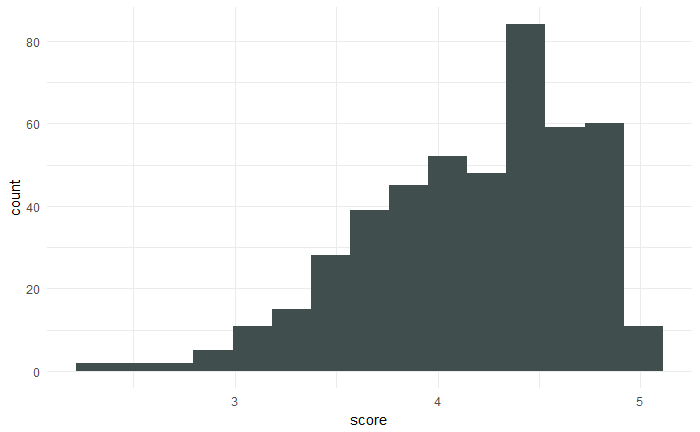

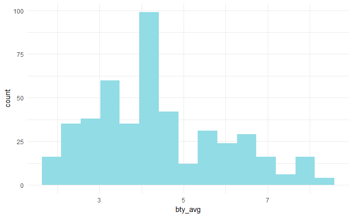

## 3. Análises

#### 3.1 Modelando o efeito da beleza do professor no seu score:

Começaremos nossa análise visualizando a relação entre as duas variáveis em questão (*score* e *bty_avg*). Lembrando que o *score* é a variável que representa a avaliação feita por vários de seus alunos, e a variável *bty_avg* é a média de beleza do professor com base na avaliação de 6 alunos. Vejamos:

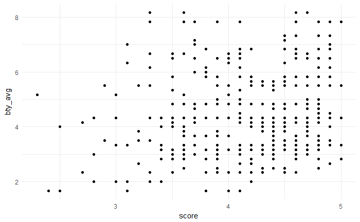

A primeira impressão é de que parece existir uma relação. Porém essa relação não é muito forte, como podemos perceber no gráfico acima. Vamos agora modelar o efeito da beleza do professor no seu *score*, e ver se chegamos à mesma conclusão. Para isso, utilizaremos regressão linear simples:

**Modelo:**

| term | estimate | std.error | statistic | p.value | conf.low | conf.high |
| --- | --- | --- | --- | --- | --- | --- |
| (Intercept) | 3.88033795 | 0.07614297 | 50.961212 | 1.561043e-191 | 3.73070764 | 4.02996827 |
| bty_avg | 0.06663704 | 0.01629115 | 4.090382 | 5.082731e-05 | 0.03462292 | 0.09865116 |

| r.squared | adj.r.squared | sigma | statistic | p.value | df | logLik | AIC | BIC | deviance | df.residual |
| --- | --- | --- | --- | --- | --- | --- | --- | --- | --- | --- |
| 0.03502226 | 0.03292903 | 0.5348351 | 16.73123 | 5.082731e-05 | 2 | -366.2225 | 738.4449 | 750.8581 | 131.8684 | 461 |

**Visualizando o modelo:**

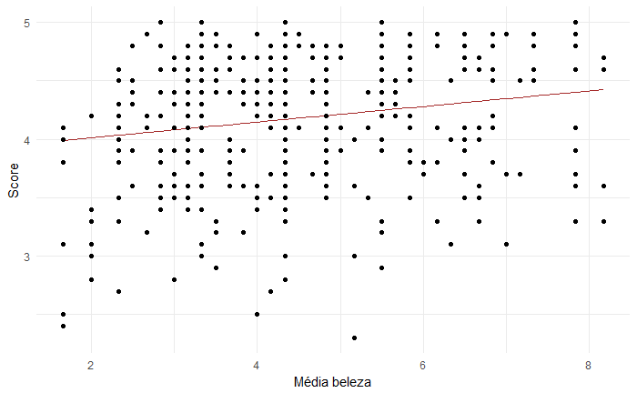

**O que podemos concluir do modelo:**

Regressão linear simples foi utilizada para analisar se a média de beleza do professor tem uma associação significativa com seu *score*. Os resultados da regressão indicam que um modelo com o preditor no formato *score = 3.88033795 + 0.06663704xbty_avg* explica apenas *3.3%* aprox. da variância da variável de resposta (*R2 = 0.03292903*). A variável *bty_avg* tem uma relação **significativa** com o erro (b = [0.03462292, 0.09865116], IC com 95%). Dizemos que a relação é significativa porque intervalo de confiança não inclui o zero. A **relevância** da beleza, no entanto, não é muito grande para o score, isso porque o aumento de 1 unidade na média de beleza do professor produz uma mudança de apenas 0.06663704 no seu score, fato observado pelo valor da estimativa associada à variável *bty_avg*.

#### 3.2 Modelo multivariado

Vamos agora utilizar um modelo que inclua outras variáveis. Queremos, com isso, explicar melhor o *score* do professor e avaliar se o efeito da beleza é significativo quando levamos em conta outras variáveis que podem explicar a variação de avaliações.

Utilizaremos as seguintes variáveis independentes nesse modelo, assumindo algumas hipóteses:

- **bty_avg:** a média da beleza.
- **gender:** o gênero do professor. Vamos ver se o gênero causa efeito nas avaliações.
- **cls_level:** o nível da disciplina, se é introdutória ou avançada. A hipótese é a de que quanto mais avançada a disciplina, maior a admiração dos alunos pelo professor. Vamos ver se isso faz sentido.
- **pic_outfit:** a roupa do professor na foto, se é formal o informal. A hipótese é a de que uma roupa informal pode dar ao aluno a ideia de proximidade com o professor, aumentando a simpatia do aluno pelo professor. Vamos ver se isso faz sentido.

**Modelo:**

| term | estimate | std.error | statistic | p.value | conf.low | conf.high |
| --- | --- | --- | --- | --- | --- | --- |
| (Intercept) | 3.82315263 | 0.11758493 | 32.513967 | 4.595652e-121 | 3.59207977 | 4.05422549 |
| bty_avg | 0.07266323 | 0.01637893 | 4.436384 | 1.147062e-05 | 0.04047606 | 0.10485041 |
| gendermale | 0.16641163 | 0.05060468 | 3.288463 | 1.084959e-03 | 0.06696548 | 0.26585777 |
| cls_levelupper | -0.07950959 | 0.05233378 | -1.519279 | 1.293824e-01 | -0.18235369 | 0.02333451 |
| pic_outfitnot formal | -0.01584957 | 0.06706596 | -0.236328 | 8.132838e-01 | -0.14764471 | 0.11594558 |

| r.squared | adj.r.squared | sigma | statistic | p.value | df | logLik | AIC | BIC | deviance | df.residual |
| --- | --- | --- | --- | --- | --- | --- | --- | --- | --- | --- |
| 0.06385044 | 0.05567446 | 0.528508 | 7.809516 | 4.283408e-06 | 5 | -359.2011 | 730.4022 | 755.2286 | 127.9289 | 458 |

**Visualizando o modelo:**

[output not shown]

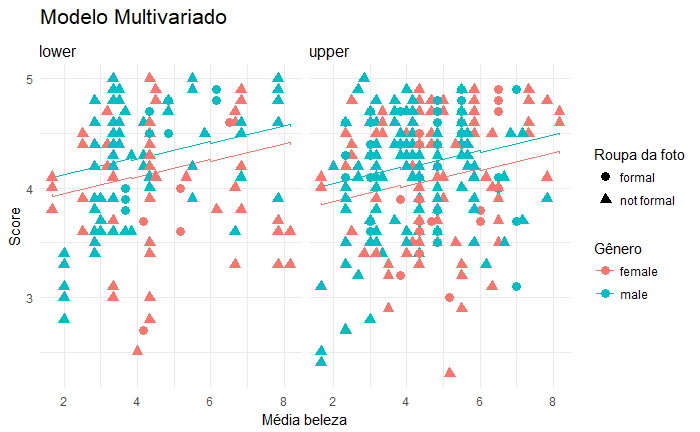

**O que podemos concluir do modelo:**

Apesar do gráfico acima ter muita informação, ele exibe todas as variáveis do modelo.

Regressão linear foi utilizada para analisar se a média de beleza, o gênero, o nível da disciplina e a formalidade da roupa do professor têm uma associação significativa com seu *score*. Os resultados da regressão indicam que um modelo com o preditor no formato *score = 3.82315263 + 0.07266323xbty_avg + 0.16641163xgendermale - 0.07950959xcls_levelupper - 0.01584957xpic_outfitnot formal* explica apenas *6.38%* aprox. da variância da variável de resposta (*R2 = 0.06385044*).

As variáveis *bty_avg* e *gender* têm uma relação **significativa**, com erros respectivos de [0.04047606, 0.10485041] e [0.06696548, 0.26585777] IC com 95% de confiança. Já as variáveis *cls_level* e *pic_outfit* não têm uma relação **significativa**, com erros respectivos de [-0.18235369, 0.02333451] e [-0.14764471, 0.11594558] IC com 95% de confiança.

Quanto às hipóteses assumidas anteriormente, podemos ver que:

- A questão do gênero realmente parece provocar um eveito no score, que tende a aumentar caso o docente seja do sexo masculino.
- Quanto ao pressuposto de que o score subiria se o nível da disciplina fosse mais avançado: o contrário foi observado.
- Quanto à hipótese de que o aluno simpatizaria mais com o professor que tivesse vestido de maneira mais informal: o contrário foi observado. Observamos, ainda, que esse foi o fator menos relevante, e ainda assim, sem significância.